# Exploring gene expression patterns using clustering methods

[back to lesson’s homepage](https://tavareshugo.github.io/data-carpentry-rnaseq/)

# Lesson Objectives

- Understand how MA plots can be useful to explore the results of differential gene expression tests
- Understand how scaling data can help in visualising gene expression trends
- Understand how clustering methods can be used to partition genes with similar trends

# Clustering basics

Similarly to what we explored in the PCA lesson, clustering methods can be helpful to group similar datapoints together.

There are different clustering algorithms and methods. Here we’re going to focus on *hierarchical clustering*, which is commonly used in exploratory data analysis. Another method that is commonly used is *k-means*, which we won’t cover here.

See this article for a nice introduction to this topic, which also uses transcriptome data: Naomi Altman & Martin Krzywinski (2017) [Clustering](https://www.nature.com/articles/nmeth.4299), Nature Methods 14, 545–546

# Visualise differences between samples using MA plots

Before starting with our gene clustering, it’s useful to reduce the dimensionality of the data and work only with those genes that are likely to show some differences of expression.

We were given a table with the results of a differential analysis test between 0 min and each of the other time-points:

```
## # A tibble: 6 x 8
##   gene        baseMean log2FoldChange lfcSE  stat pvalue  padj comparison
##   <chr>          <dbl>          <dbl> <dbl> <dbl>  <dbl> <dbl>      <dbl>
## 1 SPAC212.11      8.55         1.54   0.497 1.09   0.276     1         15
## 2 SPAC212.09c    50.8          0.399  0.273 0      1         1         15
## 3 SPAC212.04c    38.3         -0.0230 0.269 0      1         1         15
## 4 SPNCRNA.601     9.47        -0.0841 0.483 0      1         1         15
## 5 SPAC977.11     70.4         -0.819  0.201 0      1         1         15
## 6 SPAC977.13c    36.7          1.19   0.344 0.552  0.581     1         15
```

The `padj` column contains p-values (adjusted for [multiple testing](https://en.wikipedia.org/wiki/Multiple_comparisons_problem)) of each test’s `comparison`. We can therefore use this table to help us focus on a subset of potentially interesting genes.

One way to visualise the differences between T0 and the other time points is with an [MA plot](https://en.wikipedia.org/wiki/MA_plot), which shows the average expression of each gene plotted against the log-fold-change in expression between the samples:

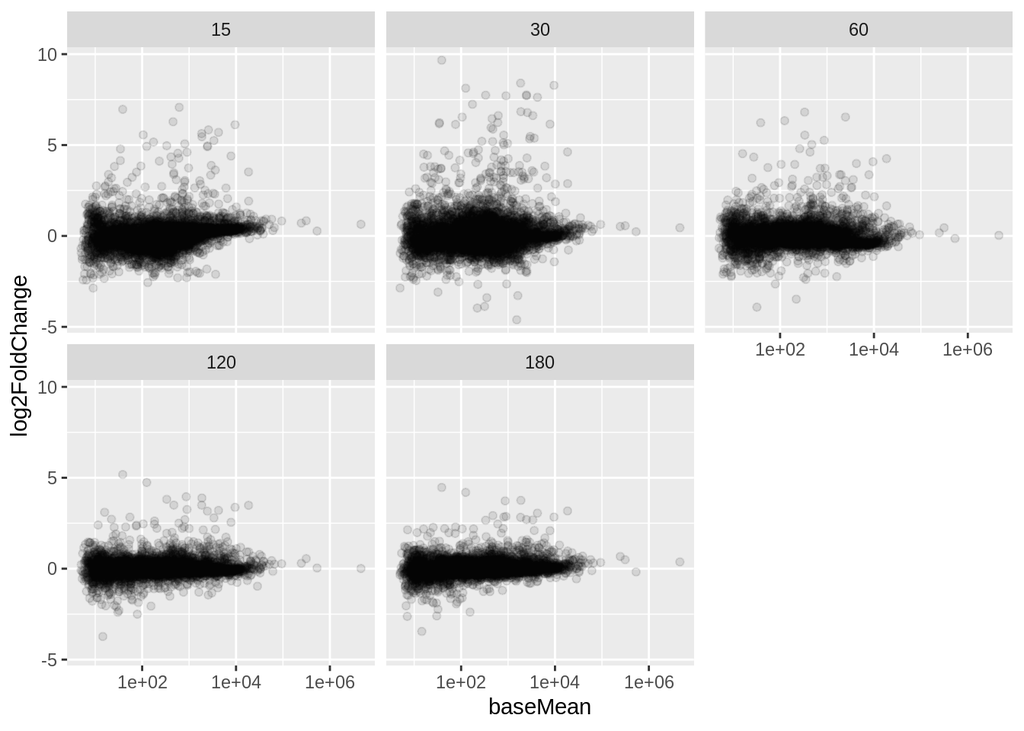

```r
test_result %>%
  ggplot(aes(baseMean, log2FoldChange)) +
  geom_point(alpha = 0.1) +
  scale_x_log10() +
  facet_wrap( ~ comparison)
```

We can further improve the visualisation of the plot above by overlaying points that are below a certain p-value threshold in a different colour:

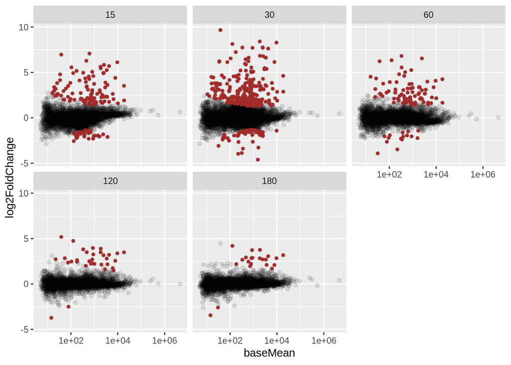

```r
test_result %>%
  # add column which contains value only if padj < 0.01
  mutate(sig = ifelse(padj < 0.01, log2FoldChange, NA)) %>%
  # make the plot
  ggplot(aes(baseMean, log2FoldChange)) +
  geom_point(alpha = 0.1) +
  geom_point(aes(y = sig), colour = "brown", size = 1) +
  scale_x_log10() +
  facet_wrap( ~ comparison)
```

The plot above is in agreement with our PCA analysis, which showed that cells from T30 were overall transcriptomically quite distinct from T0 cells.

From the coloured clouds of points, we can also seen that more genes seem to markedly increase than decrease their expression in relation to T0.

# Scaling data to improve visualisation of expression trends

Now, let’s focus on those genes where `padj < 0.01` for any of the time-points and then see how their expression changes across time.

We start by extracting the genes of interest based on our criteria:

```r
candidate_genes <- test_result %>%
  filter(padj < 0.01) %>%          # filter table
  pull(gene) %>%                   # extract the gene column as a vector
  unique()                         # retain only unique values
```

We then use this vector to subset out table of transformed counts and summarise our counts to get average counts per time point:

```r
norm_cts_mean <- norm_cts_long %>%
  filter(gene %in% candidate_genes) %>%
  group_by(gene, strain, minute) %>%
  summarise(mean_cts = mean(cts),
            nrep = n()) %>%
  ungroup()

head(norm_cts_mean)
```

```
## # A tibble: 6 x 5
##   gene         strain minute mean_cts  nrep
##   <chr>        <fct>  <fct>     <dbl> <int>
## 1 SPAC1002.17c wt     0          6.23     3
## 2 SPAC1002.17c wt     15         6.71     3
## 3 SPAC1002.17c wt     30         7.85     3
## 4 SPAC1002.17c wt     60         9.41     3
## 5 SPAC1002.17c wt     120        5.83     3
## 6 SPAC1002.17c wt     180        6.07     3
```

We want to explore *patterns* of expression across time in the two strains. We can plot each gene’s expression across time, but the result is very confusing!

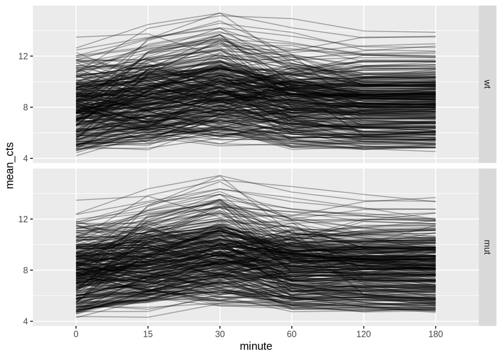

```r
norm_cts_mean %>%
  ggplot(aes(minute, mean_cts)) +
  geom_line(aes(group = gene), alpha = 0.3) +
  facet_grid(strain ~ .)
```

When we are interested in *relative* patterns of expression, it is very useful to transform our data to ensure that the different genes are represented on a comparable scale.

You could imagine that two genes might have changed by the same magnitude (say, doubled the expression between time points), but their base mean levels of expression might have been quite different. For example, one gene might have changed from 10 to 20 and another from 100 to 200.

If what we’re interested in is the *relative change* in expression, then those two genes will appear more different than they really are in our plots.

A useful data transformation in this case is to center and scale each genes’ expression by their mean and standard deviation, respectively. The values thus obtained are known as [z-scores](https://en.wikipedia.org/wiki/Standard_score), and can be interpreted as the “number of standard deviations away from the mean”. A positive z-score means that the gene’s expression was above the average across samples, whereas a negative one means it was below average. A value of zero means the gene’s expression was exactly average.

In R, we can use the function scale to do this transformation. Let’s re-do our data summary, but scale the each gene’s expression data first:

```r
norm_cts_mean <- norm_cts_long %>%
  # filter to retain only genes of interest
  filter(gene %in% candidate_genes) %>%
  # for each gene
  group_by(gene) %>%
  # scale the cts column
  mutate(cts_scaled = scale(cts)) %>%
  # for each gene, strain and minute
  group_by(gene, strain, minute) %>%
  # calculate the mean (scaled) cts
  summarise(mean_cts_scaled = mean(cts_scaled),
            nrep = n()) %>%
  ungroup()
```

And now we can re-do the plot, and see how this transformation changes our perception of the data:

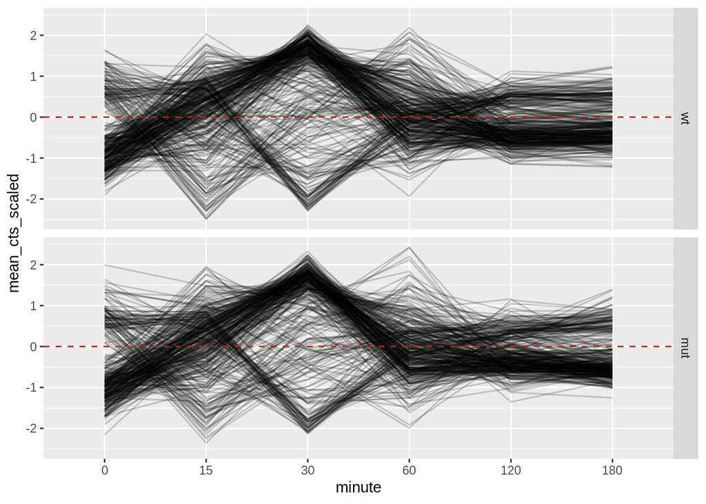

```r
norm_cts_mean %>%
  ggplot(aes(minute, mean_cts_scaled)) +
  geom_line(aes(group = gene), alpha = 0.2) +
  geom_hline(yintercept = 0, colour = "brown", linetype = "dashed") +
  facet_grid(strain ~ .)
```

As you see, this is a substantially clearer picture than before, we can clearly see some patterns there. It’s not perfect yet: as you can see there are different “populations” of genes with different trends. Our next goal is to try and partition the genes into different categories and separate them out.

# Gene partitioning using hierarchical clustering

We will use *hierarchical clustering* to try and find some structure in our gene expression trends, and partition our genes into different clusters.

There’s two steps to this clustering procedure:

- Calculate a “distance” metric between each pair of genes
- Cluster the genes hierarchically using a particular agglomeration method

There are many choices that can be made at both steps. We will use a simple *euclidean distance* metric and *complete linkage* clustering method, which work well for these data (but you can experiment with other metrics/methods, that’s why it’s called “exploratory analysis”!).

In R, we can use the `dist()` function for the first step and `hclust()` for the second step.

## Calculating distance between samples using `dist()`

The `dist()` function works best with a *matrix* of data. Therefore, we’re going to use our original matrix of counts stored in `norm_cts`. However, we do not want to use all of the genes in that matrix, but rather the subset of genes that we think are differentially expressed between time points.

To subset a matrix, we need to use the “square bracket” notation `[rows , columns]`. Because the rows on our matrix are named, we can use our vector of gene names created above (`candidate_genes`) to do this:

```r
norm_cts[candidate_genes, ]
```

After this step, we want to **scale** the data (to obtain z-scores). The `scale()` function can be used with a matrix, where it will scale each *column* by its mean and standard deviation. However, we want to scale the expression of our *genes*, which are the *rows* of the matrix! So, we need to do a little gymnastics here, and first transpose our matrix, then scale, then transpose it back again.

We can do it with pipes, which makes the order of operations quite clear:

```r
norm_cts[candidate_genes, ] %>%
  # transpose the matrix so genes are as columns
  t() %>%
  # apply scalling to each column of the matrix (genes)
  scale() %>%
  # transpose back so genes are as rows again
  t()
```

Finally, we can complete this pipeline by calculating the distance between each gene (*row*) in our matrix:

```r
gene_dist <- norm_cts[candidate_genes, ] %>%
  t() %>%
  scale() %>%
  t() %>%
  dist()
```

## Perform hierarchical clustering using `hclust()`

With this distance matrix, we are ready to apply the `hclust()` function:

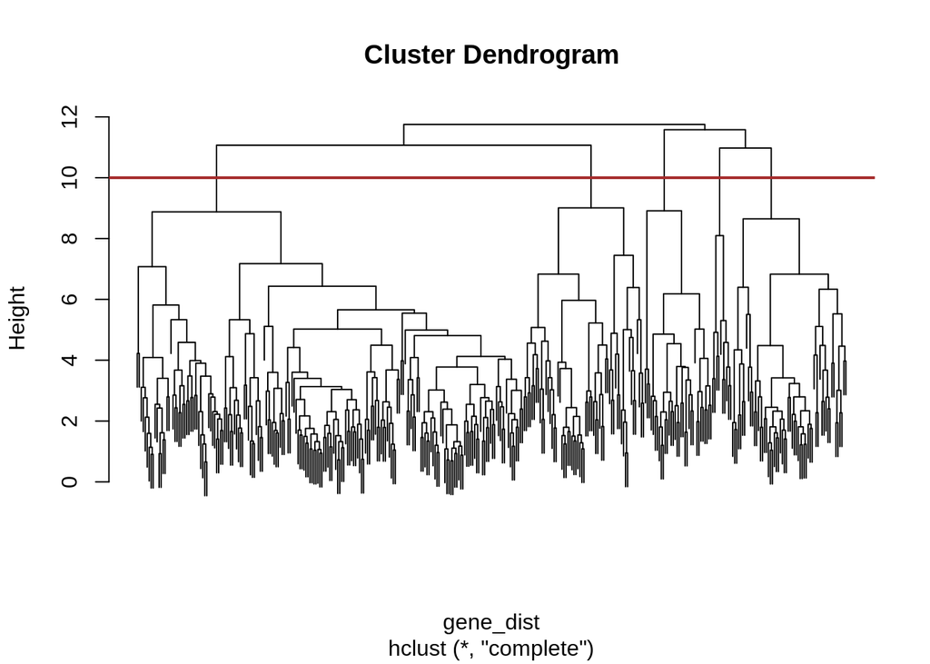

```r
gene_hclust <- hclust(gene_dist, method = "complete")

# The default `plot()` function can be used to produce a simple dendrogram
plot(gene_hclust, labels = FALSE)
abline(h = 10, col = "brown", lwd = 2) # add horizontal line to illustrate cutting dendrogram
```

From the dendrogram above, we can see there’s substantial structure in our data. We can use the dendrogram to visualy determine how many groups we think are worth focusing on. You can imagine having an horizontal line that you slide down the dendrogram, cutting it into different groups (e.g. the brown line shown above).

We can use the `cutree()` function do this dendrogram “cutting”. For example, if you want to cut it into 5 groups, you would simply do:

[output not shown]

```r
cutree(gene_hclust, k = 5)
```

The output of `cutree()` is a named vector, where each gene is assigned to a cluster number (the numbers are somewhat arbitrary, but genes with the same number belong to the same cluster.

For analysis purposes, it’s convenient to convert this vector into a `tibble`, so we can join it with our table of gene expression counts that will be used to make a plot:

```r
gene_cluster <- cutree(gene_hclust, k = 5) %>%
  # turn the named vector into a tibble
  enframe() %>%
  # rename some of the columns
  rename(gene = name, cluster = value)

head(gene_cluster)
```

```
## # A tibble: 6 x 2
##   gene          cluster
##   <chr>           <int>
## 1 SPAC11D3.05         1
## 2 SPAC5H10.13c        2
## 3 SPAC13C5.04         1
## 4 SPAC2G11.12         2
## 5 SPAC821.09          3
## 6 SPAC22A12.17c       1
```

## Visualise gene expression trends per cluster

Finally, we are ready to visualise our gene expression trends, but separate our genes into their respective clusters.

First, let’s join our table with gene clusters to the table of gene summarised counts that we produced above:

```r
norm_cts_cluster <- norm_cts_mean %>%
  inner_join(gene_cluster, by = "gene")

head(norm_cts_cluster)
```

```
## # A tibble: 6 x 6
##   gene         strain minute mean_cts_scaled  nrep cluster
##   <chr>        <fct>  <fct>            <dbl> <int>   <int>
## 1 SPAC1002.17c wt     0               -0.520     3       4
## 2 SPAC1002.17c wt     15              -0.230     3       4
## 3 SPAC1002.17c wt     30               0.458     3       4
## 4 SPAC1002.17c wt     60               1.40      3       4
## 5 SPAC1002.17c wt     120             -0.762     3       4
## 6 SPAC1002.17c wt     180             -0.615     3       4
```

And now we can make a plot, facetting according to `strain` and `cluster`:

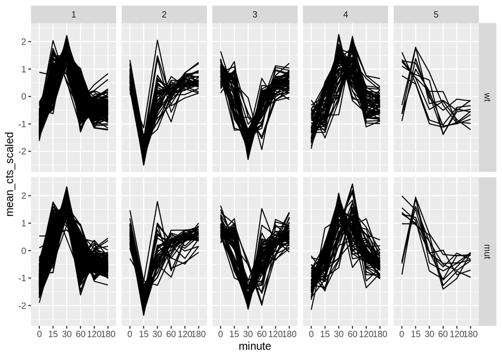

```r
norm_cts_cluster %>%
  ggplot(aes(minute, mean_cts_scaled)) +
  geom_line(aes(group = gene)) +
  facet_grid(strain ~ cluster)
```

This is a much nicer picture, as we can now see how different clusters represent genes with (broadly) similar expression trends. It’s still not perfect, and you can play around by cutting the tree into even more groups and re-doing these plots.

It is worth pointing out that this result is not entirely surprising. Since we pre-filtered our genes to include those that showed marked difference between T0 and any of the other time points, it’s no surprise that our genes partition into groups having a peak (or dip) of expression at a particular time-point. However, this analysis illustrates how clustering can be used to help partition genes according to particular patterns, regardless of how you pre-selected them.

Finally, here is an advanced `ggplot2` trick to add a line to each facet showing the median expression in each cluster:

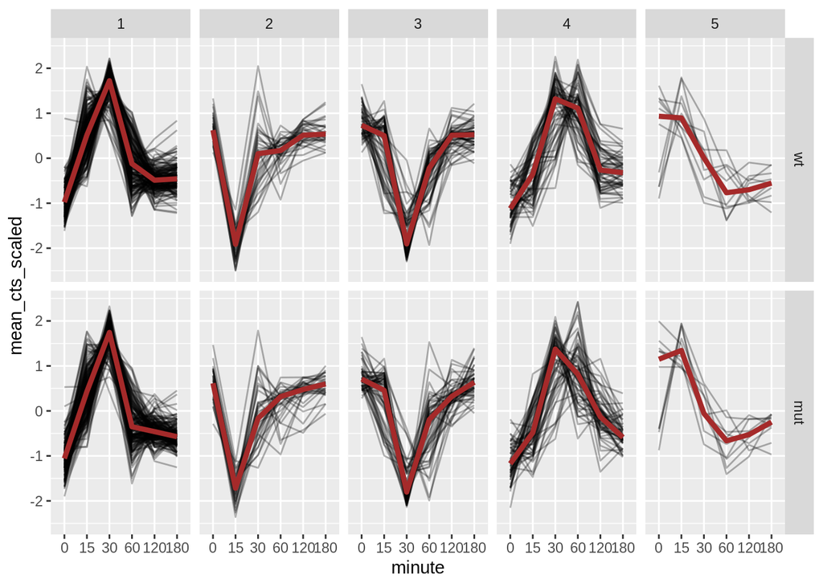

```r
norm_cts_cluster %>%
  ggplot(aes(minute, mean_cts_scaled)) +
  geom_line(aes(group = gene), alpha = 0.3) +
  geom_line(stat = "summary", fun.y = "median", colour = "brown", size = 1.5,
            aes(group = 1)) +
  facet_grid(strain ~ cluster)
```

[back to lesson’s homepage](https://tavareshugo.github.io/data-carpentry-rnaseq/)